# NormScore assessment - Simulation results

Executions in Finis Terrae III (CESGA)

Julia García Currás

julia.gcurras@biostatech.com

23 April 2026

[figure not shown]

# 1 Simulations

A first evaluation of the normScore was performed using simulation datasets.

Description:

- Nine different datasets were simulated with an increasing error for each item or group of items.
- The previous combination of 9 datasets was repeated several times changing the following parameters:
  - Magnitude of error: 0 (no error), 1-8 (increased error).
  - Number of proteins: 100, 1000, 5000, 10000.
  - Number of samples per group: 5, 10, 20, 50.
- These simulations were also repeated 20 times using different seeds.

In addtition, five different errors were necessary to assess all items:

- Item 0, 1, 5 and 6: shift error
- Item 2: correlation between/within magnitude
- Item 3: shift+residual variance
- Item 4: mean-SD dependence
- normScore: a general combination of shift error, correlation magnitude, residual variance magnitude and dependence of mean-SD

For each combination of parameters (magnitude of error, no. proteins, no. samples/group, repetition), the item/normScore was used to assess the 9 simulated datasets. The resulting order was compared with the expected one (datasets 0 to 8 sorted from higher to lower quality) using the Kendall correlation coefficient. A total number of 1.44^{4} Kendall correlation coefficients was obtained and used in this report to assess the performance of each item and the global score.

# 2 Results

## 2.1 By item

|  | Item0 (N=320) | Item1 (N=320) | Item2 (N=320) | Item3 (N=320) | Item4 (N=320) | Item5 (N=320) | Item6 (N=320) | normScore (N=320) | Total (N=2560) |
| --- | --- | --- | --- | --- | --- | --- | --- | --- | --- |
| Type of error (1) |  |  |  |  |  |  |  |  |  |
| - N | 320 | 320 | 320 | 320 | 320 | 320 | 320 | 320 | 2560 |
| - Mean (SD) | -0.03 (0.27) | -0.01 (0.27) | -0.00 (0.26) | 0.02 (0.27) | 0.00 (0.27) | -0.02 (0.28) | 0.02 (0.27) | 0.00 (0.26) | -0.00 (0.27) |
| - Median (Q1, Q3) | 0.00 (-0.22, 0.17) | -0.06 (-0.17, 0.17) | 0.00 (-0.17, 0.17) | 0.00 (-0.17, 0.22) | 0.00 (-0.17, 0.22) | -0.06 (-0.22, 0.17) | 0.00 (-0.17, 0.22) | 0.00 (-0.17, 0.17) | 0.00 (-0.17, 0.17) |
| - Range | -0.72 - 0.72 | -0.94 - 0.72 | -0.72 - 0.67 | -0.67 - 0.78 | -0.67 - 0.72 | -0.83 - 0.83 | -0.72 - 0.72 | -0.83 - 0.67 | -0.94 - 0.83 |
| Type of error (2) |  |  |  |  |  |  |  |  |  |
| - N | 320 | 320 | 320 | 320 | 320 | 320 | 320 | 320 | 2560 |
| - Mean (SD) | 1.00 (0.02) | 1.00 (0.01) | 0.98 (0.04) | 0.68 (0.48) | 1.00 (0.00) | 1.00 (0.02) | 0.99 (0.03) | 0.88 (0.12) | 0.94 (0.21) |
| - Median (Q1, Q3) | 1.00 (1.00, 1.00) | 1.00 (1.00, 1.00) | 1.00 (0.94, 1.00) | 0.94 (0.50, 1.00) | 1.00 (1.00, 1.00) | 1.00 (1.00, 1.00) | 1.00 (1.00, 1.00) | 0.89 (0.83, 0.94) | 1.00 (1.00, 1.00) |
| - Range | 0.89 - 1.00 | 0.89 - 1.00 | 0.78 - 1.00 | -0.94 - 1.00 | 1.00 - 1.00 | 0.78 - 1.00 | 0.78 - 1.00 | 0.28 - 1.00 | -0.94 - 1.00 |

[output cut: 20 more lines]

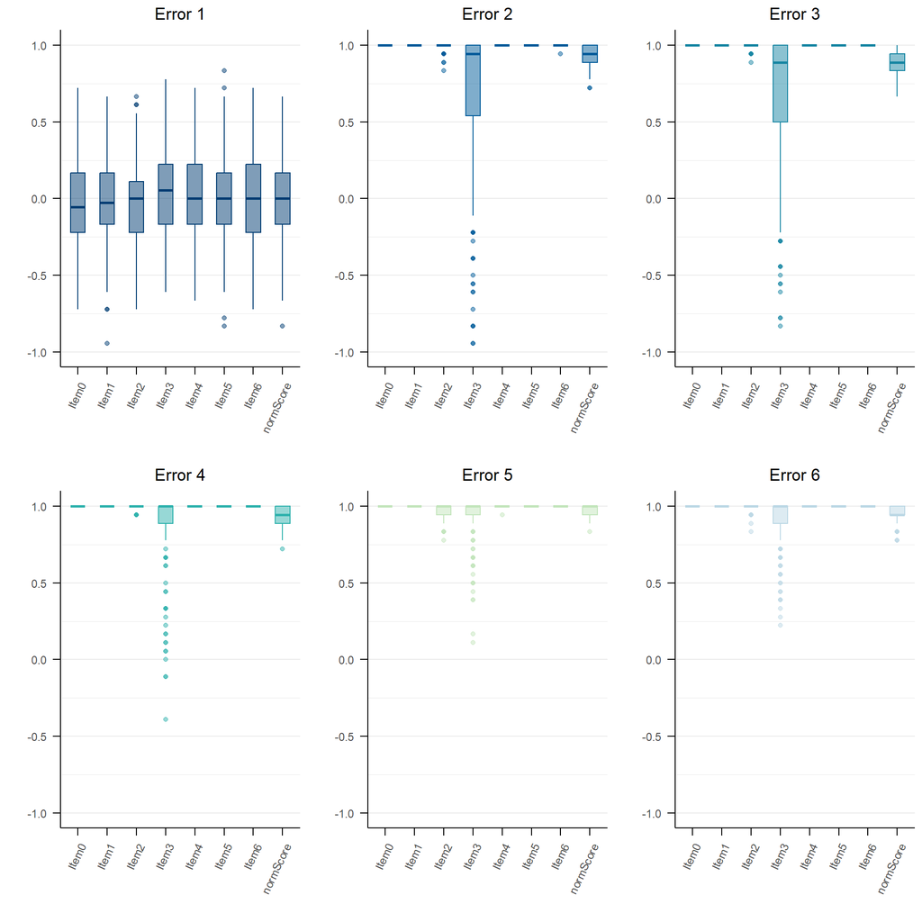

## 2.2 By nº. proteins

|  | Item0 (N=400) | Item1 (N=400) | Item2 (N=400) | Item3 (N=400) | Item4 (N=400) | Item5 (N=400) | Item6 (N=400) | normScore (N=400) | Total (N=3200) |
| --- | --- | --- | --- | --- | --- | --- | --- | --- | --- |
| Nº proteins:100 |  |  |  |  |  |  |  |  |  |
| - N | 400 | 400 | 400 | 400 | 400 | 400 | 400 | 400 | 3200 |
| - Mean (SD) | 1.00 (0.01) | 1.00 (0.01) | 0.96 (0.07) | 0.84 (0.27) | 1.00 (0.01) | 1.00 (0.02) | 0.99 (0.02) | 0.87 (0.12) | 0.96 (0.12) |
| - Median (Q1, Q3) | 1.00 (1.00, 1.00) | 1.00 (1.00, 1.00) | 1.00 (0.94, 1.00) | 0.94 (0.78, 1.00) | 1.00 (1.00, 1.00) | 1.00 (1.00, 1.00) | 1.00 (1.00, 1.00) | 0.89 (0.83, 0.94) | 1.00 (0.94, 1.00) |
| - Range | 0.89 - 1.00 | 0.89 - 1.00 | 0.39 - 1.00 | -0.56 - 1.00 | 0.83 - 1.00 | 0.78 - 1.00 | 0.78 - 1.00 | 0.28 - 1.00 | -0.56 - 1.00 |
| Nº proteins:1000 |  |  |  |  |  |  |  |  |  |
| - N | 400 | 400 | 400 | 400 | 400 | 400 | 400 | 400 | 3200 |
| - Mean (SD) | 1.00 (0.00) | 1.00 (0.00) | 0.97 (0.05) | 0.81 (0.36) | 1.00 (0.01) | 1.00 (0.00) | 1.00 (0.01) | 0.91 (0.09) | 0.96 (0.15) |
| - Median (Q1, Q3) | 1.00 (1.00, 1.00) | 1.00 (1.00, 1.00) | 1.00 (0.94, 1.00) | 1.00 (0.78, 1.00) | 1.00 (1.00, 1.00) | 1.00 (1.00, 1.00) | 1.00 (1.00, 1.00) | 0.94 (0.89, 0.94) | 1.00 (1.00, 1.00) |
| - Range | 1.00 - 1.00 | 1.00 - 1.00 | 0.67 - 1.00 | -0.94 - 1.00 | 0.89 - 1.00 | 0.94 - 1.00 | 0.89 - 1.00 | 0.33 - 1.00 | -0.94 - 1.00 |

[output cut: 10 more lines]

### All

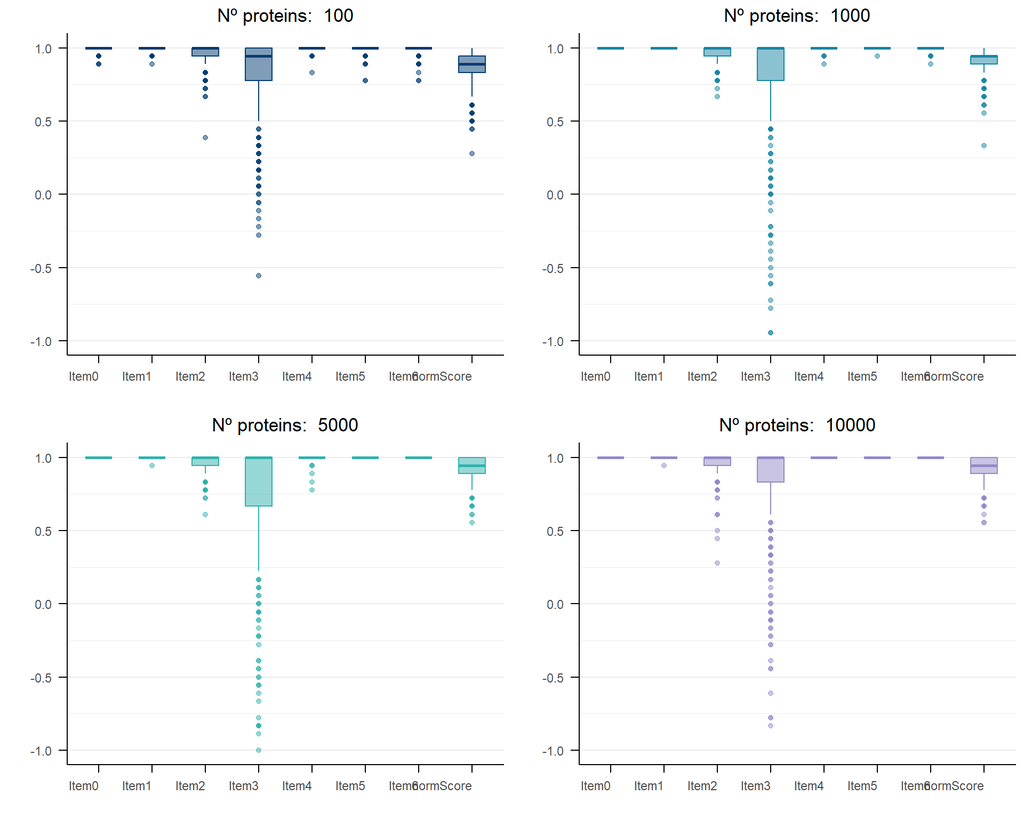

### Error 2

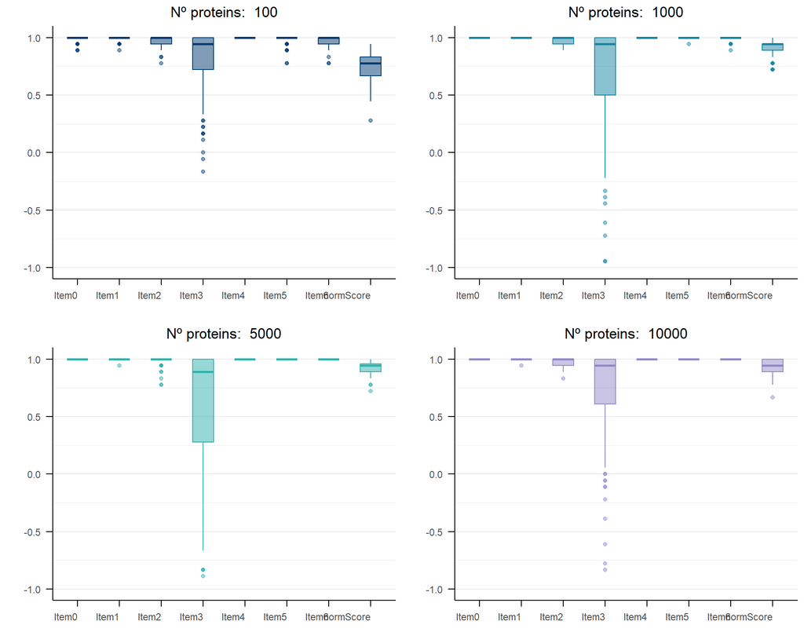

### Error 3

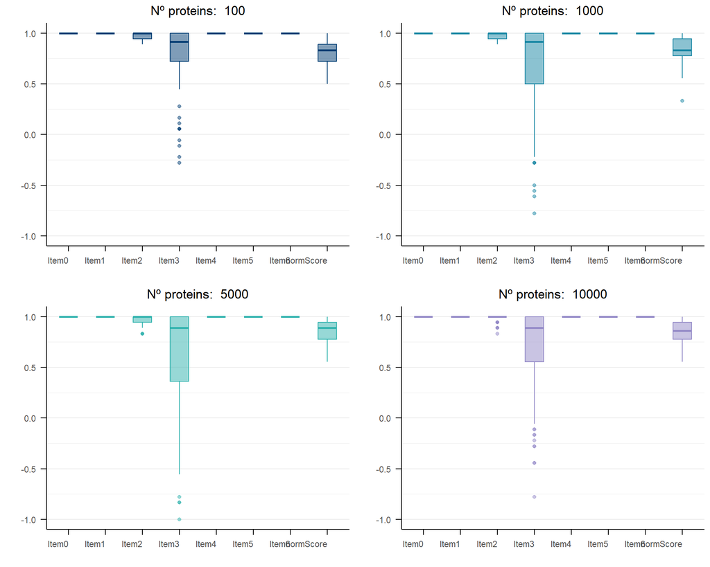

### Error 4

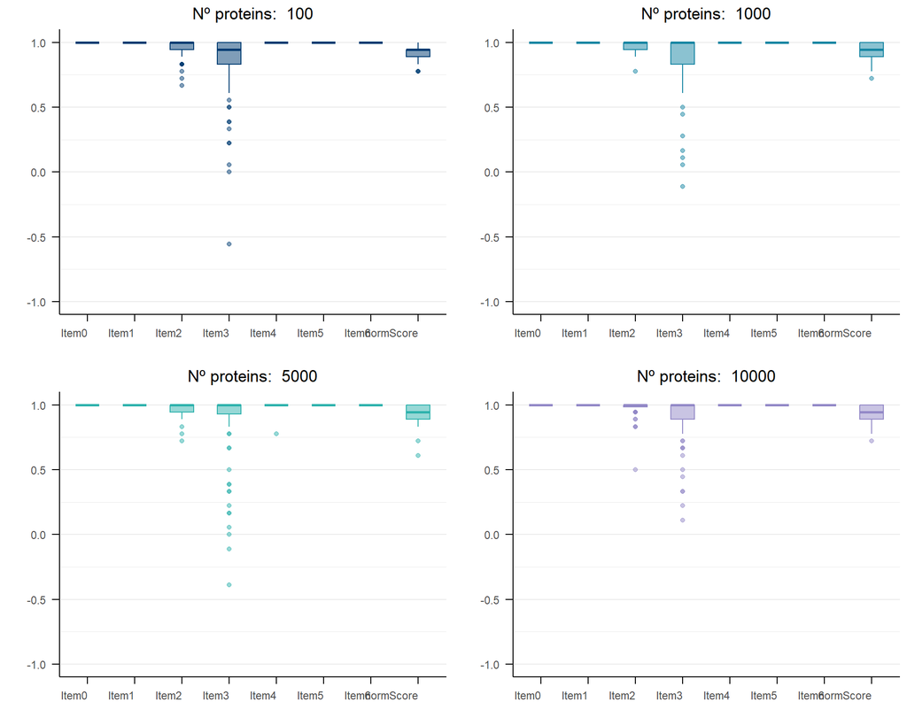

### Error 5

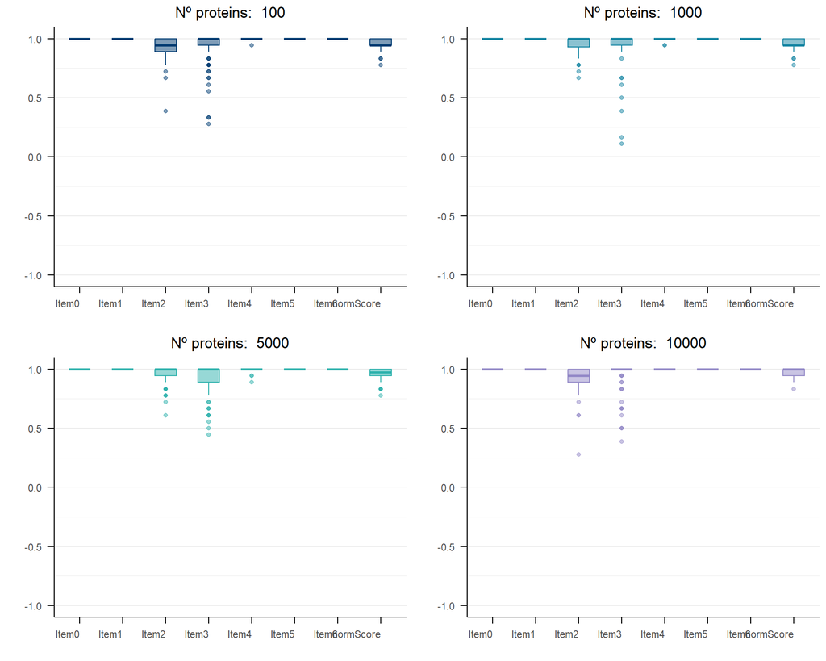

### Error 6

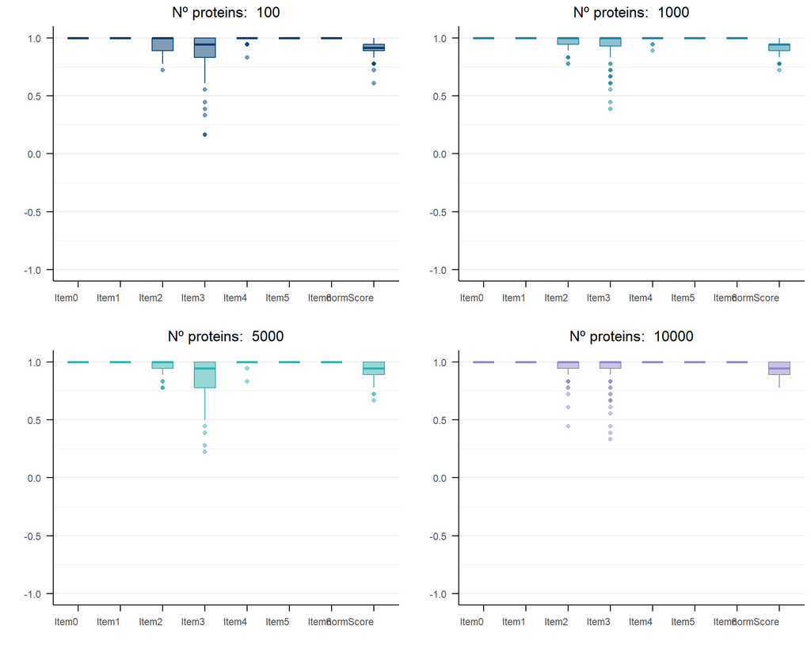

## 2.3 By nº. samples/group

|  | Item0 (N=480) | Item1 (N=480) | Item2 (N=480) | Item3 (N=480) | Item4 (N=480) | Item5 (N=480) | Item6 (N=480) | normScore (N=480) | Total (N=3840) |
| --- | --- | --- | --- | --- | --- | --- | --- | --- | --- |
| Nº samples/group: 5 |  |  |  |  |  |  |  |  |  |
| - N | 480 | 480 | 480 | 480 | 480 | 480 | 480 | 480 | 3840 |
| - Mean (SD) | 0.83 (0.40) | 0.83 (0.39) | 0.75 (0.37) | 0.66 (0.47) | 0.83 (0.39) | 0.83 (0.40) | 0.83 (0.40) | 0.71 (0.35) | 0.78 (0.40) |
| - Median (Q1, Q3) | 1.00 (1.00, 1.00) | 1.00 (1.00, 1.00) | 0.89 (0.78, 0.94) | 0.94 (0.43, 1.00) | 1.00 (1.00, 1.00) | 1.00 (1.00, 1.00) | 1.00 (1.00, 1.00) | 0.83 (0.67, 0.94) | 1.00 (0.83, 1.00) |
| - Range | -0.72 - 1.00 | -0.61 - 1.00 | -0.56 - 1.00 | -1.00 - 1.00 | -0.61 - 1.00 | -0.61 - 1.00 | -0.67 - 1.00 | -0.67 - 1.00 | -1.00 - 1.00 |
| Nº samples/group: 10 |  |  |  |  |  |  |  |  |  |
| - N | 480 | 480 | 480 | 480 | 480 | 480 | 480 | 480 | 3840 |
| - Mean (SD) | 0.82 (0.41) | 0.83 (0.40) | 0.81 (0.39) | 0.68 (0.46) | 0.84 (0.38) | 0.82 (0.41) | 0.84 (0.37) | 0.75 (0.36) | 0.80 (0.40) |
| - Median (Q1, Q3) | 1.00 (1.00, 1.00) | 1.00 (1.00, 1.00) | 0.94 (0.94, 1.00) | 0.94 (0.44, 1.00) | 1.00 (1.00, 1.00) | 1.00 (1.00, 1.00) | 1.00 (1.00, 1.00) | 0.89 (0.78, 0.94) | 1.00 (0.89, 1.00) |
| - Range | -0.72 - 1.00 | -0.94 - 1.00 | -0.72 - 1.00 | -0.94 - 1.00 | -0.61 - 1.00 | -0.83 - 1.00 | -0.72 - 1.00 | -0.61 - 1.00 | -0.94 - 1.00 |

[output cut: 10 more lines]

### All

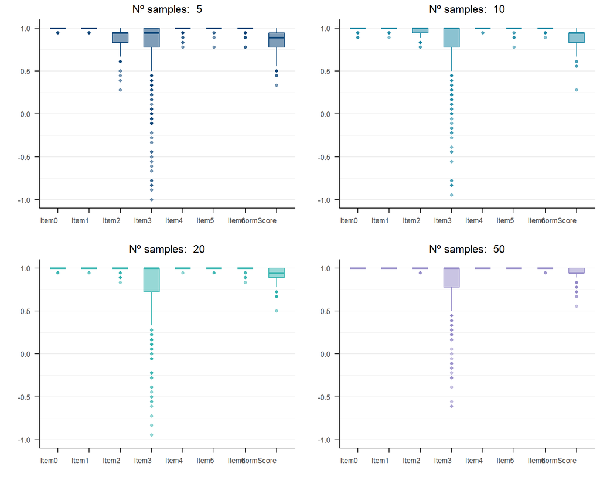

### Error 2

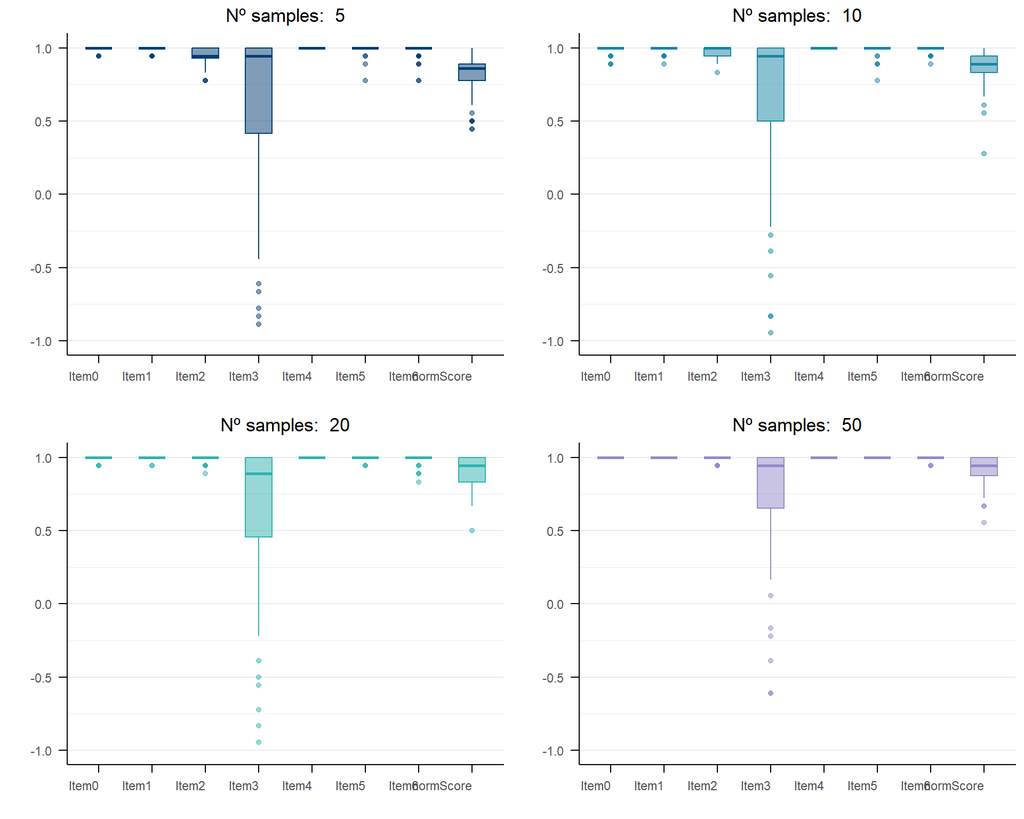

### Error 3

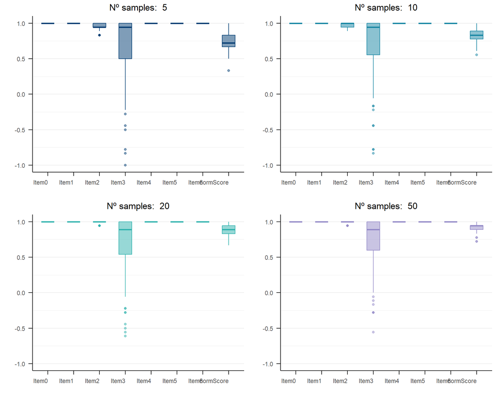

### Error 4

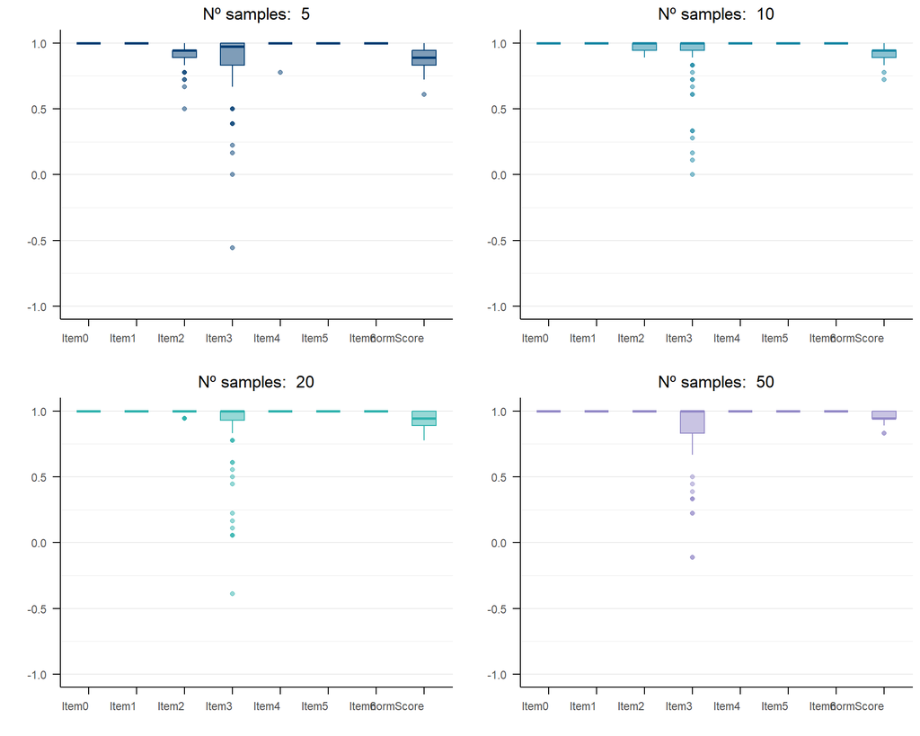

### Error 5

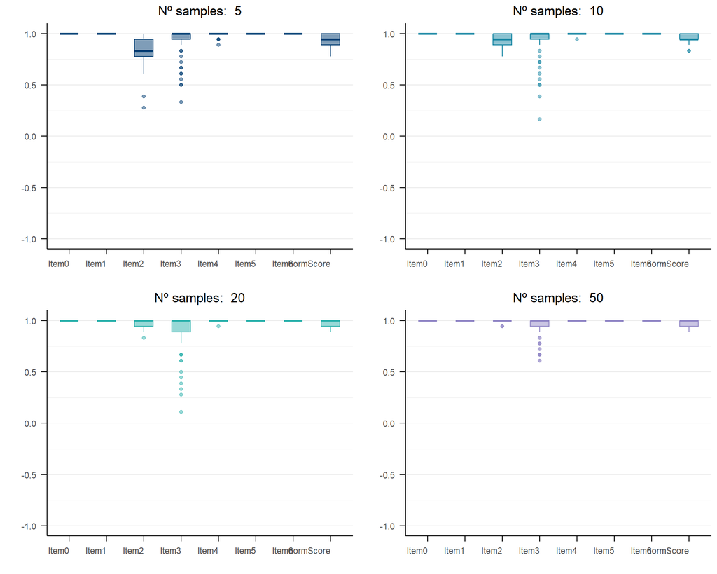

### Error 6

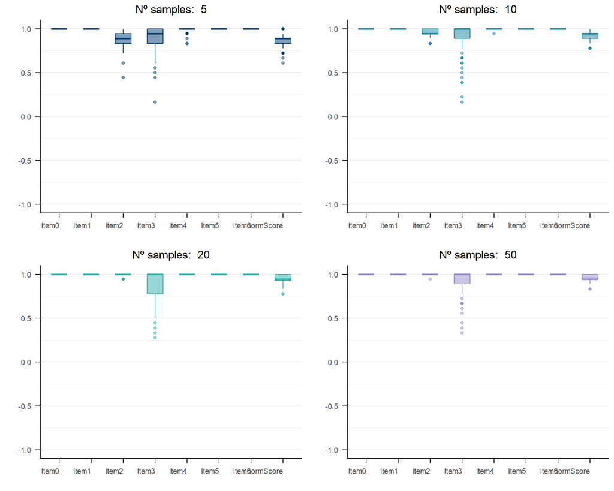

[output not shown]

[output cut: 90 more lines]

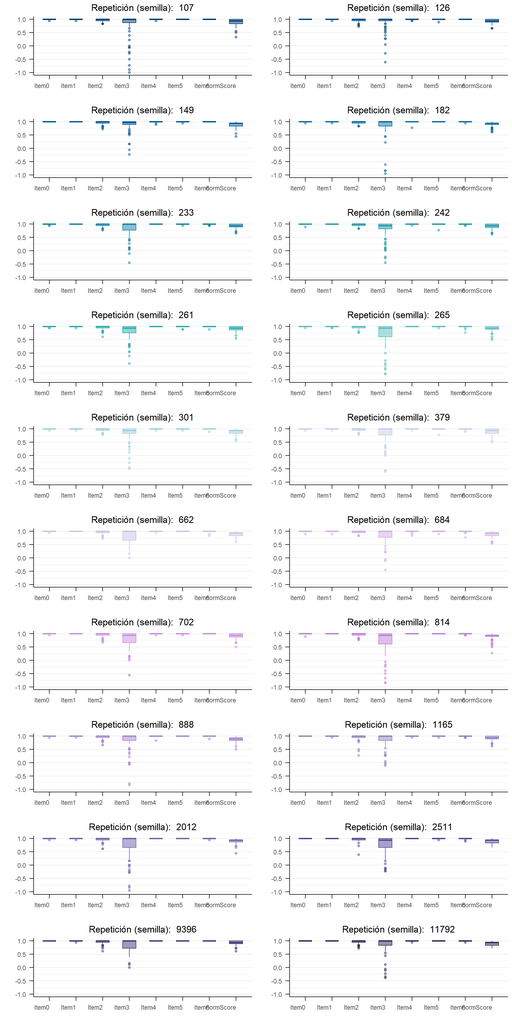

# 3 Summary

General performance of normScore is slightly lower in terms of median, but with almost no extreme or outlier correlation values and thin IQR values.

*Especificos* 1 and 8 combinations correspond to extrem conditions and were be removed for reporting the final results.

*Notas:*

Julia García Currás

Biostatech. Advice, Training & Innovation in Biostatistics S.L.

*julia.garcia@biostatech.com*